# SNAG: Hormones

Shuying Yu

1/9/2022

# Overview

Data has been cleaned into tidy format prior to analysis.

For hormones and behavior correlations, I want to keep participants that have 1) SNAG data *and* 2) hormones data. Men and women will be kept separate for analyses because they were tested for different sex steroid hormones.

Men were tested for SHBG, DHEAS, and testosterone if they had a scan. If they did a follow-up spatial session or had no scan, they were only tested for SHBG and testosterone, or just SHBG.

# Correlations

Current sample sizes for behavior $\times$ sex hormones (participants with behavior for analysis):

*Male*

- LOOP: 23
- MAZE: 14
- DSP: 21

*Female*

- LOOP: 32
- MAZE: 25
- DSP: 19

The following figures and Pearson’s *r* correlation analyses are preliminary and exploratory. The hormone data were taken from when the SNAG study coincided with the blood draws (i.e., if participants did a follow-up SNAG, hormone data was taken from that time point and not when scan was done). See summary section for future considerations. Thus, sample sizes differ not just by task, but also by sex hormone.

The 95% confidence interval is drawn with the line of best fit. Data points with missing hormone data are not plotted (dropped automatically) so they do not skew the correlation analyses or the line of best fit.

## Male

### LOOP

#### Position Error

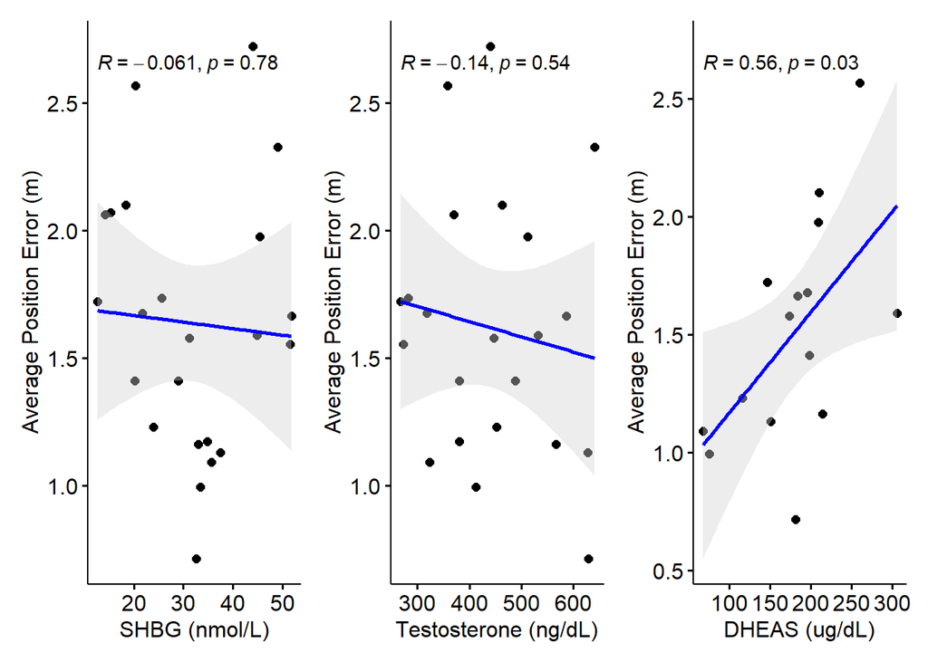

For LOOP position error, DHEAS seems to be positively associated with behavior for men.

#### Degrees Traveled

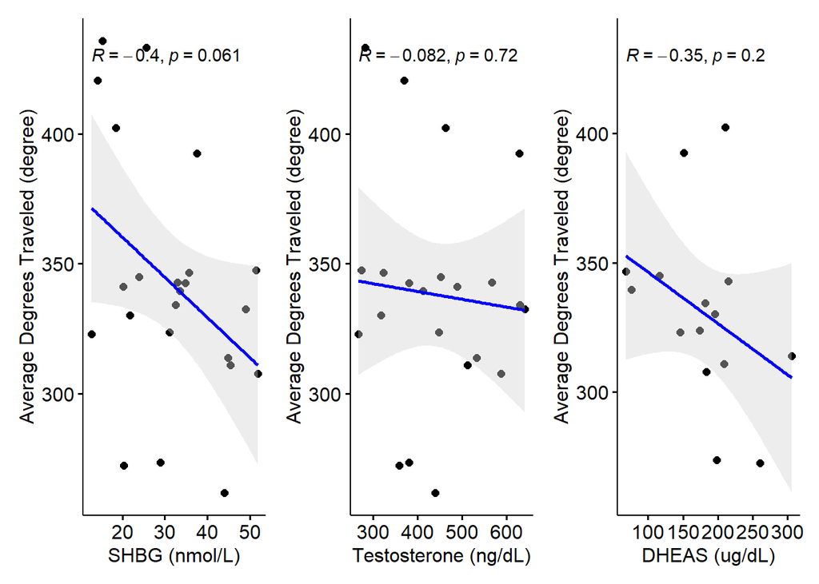

For LOOP degrees traveled, it seems to have a negative trend with hormones overall in men. SHBG seems to be marginally and negatively correlated with degrees traveled.

### MAZE

#### Accuracy

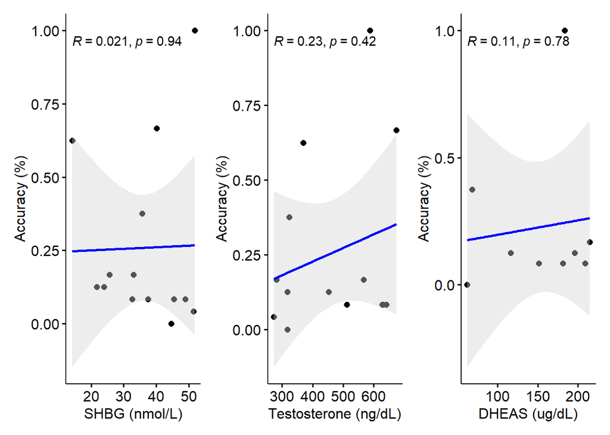

No associations between MAZE accuracy and hormones for men.

#### Moves

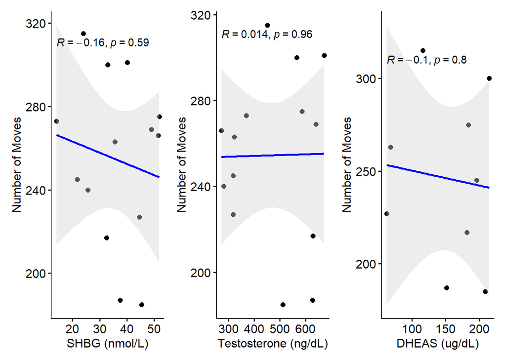

Also no association between MAZE number of moves and hormones for men.

### DSP

#### Wayfinding Success

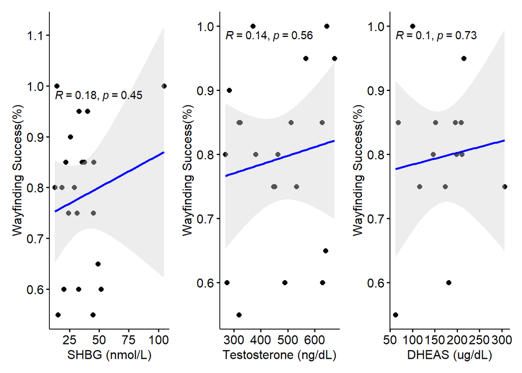

Generally looks like a positive trend, but overall no associations between DSP wayfinding success and hormones for men.

#### Solution Index

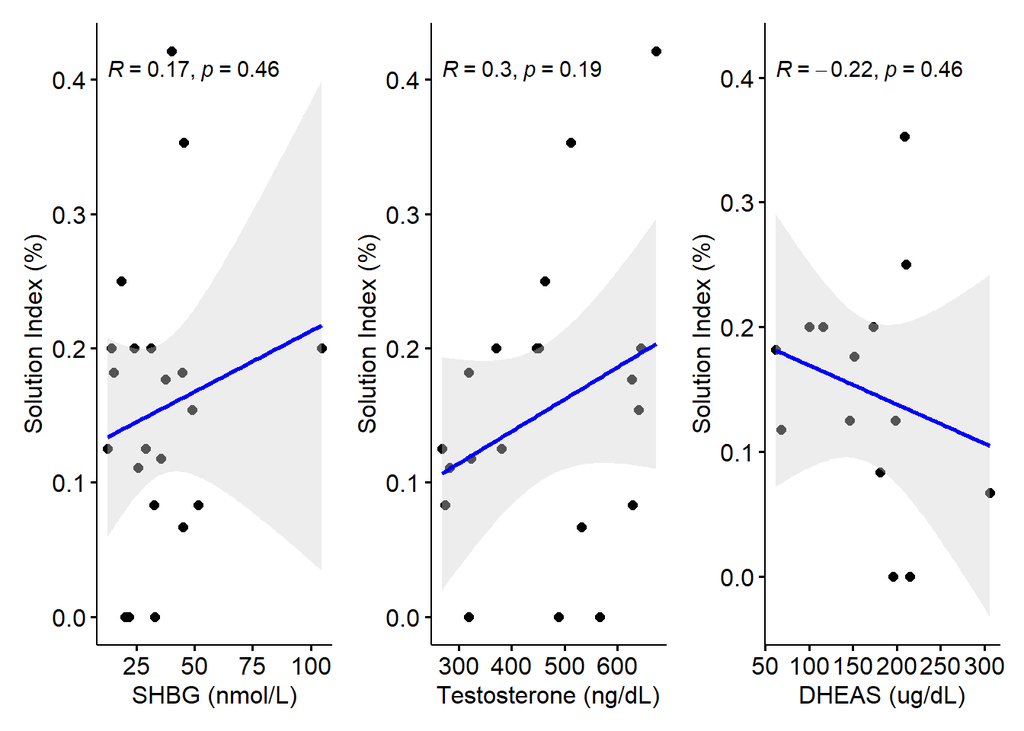

No association between DSP solution index and hormones for men.

## Female

### LOOP

#### Position Error

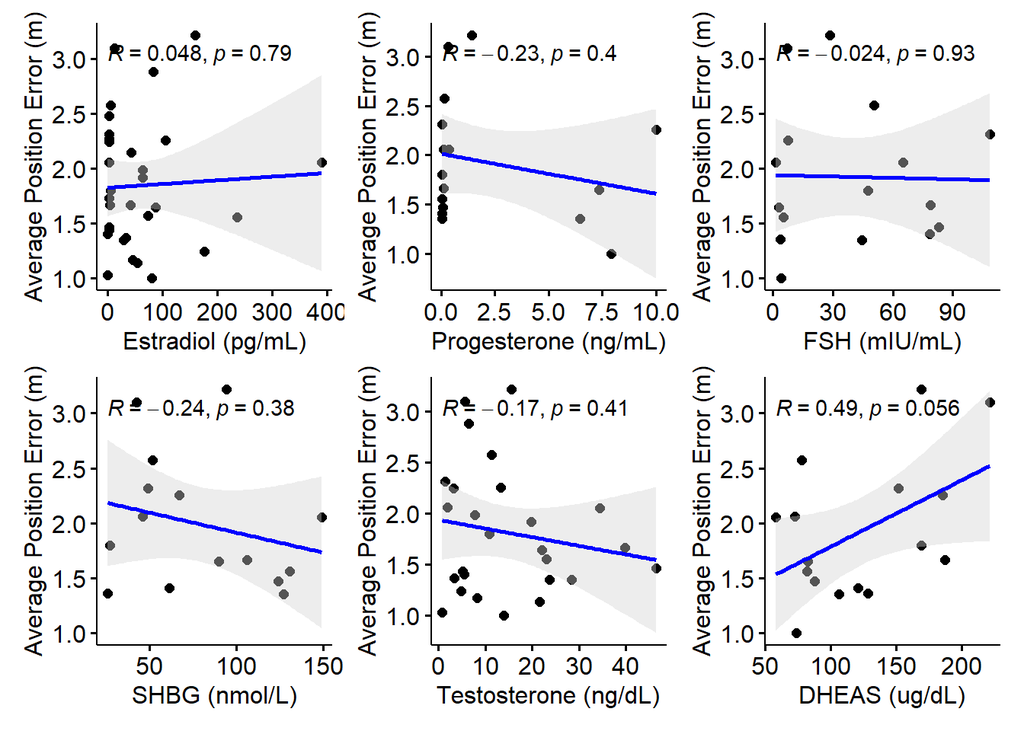

For LOOP position error, there is a positive trend with DHEAS for women.

#### Degrees Traveled

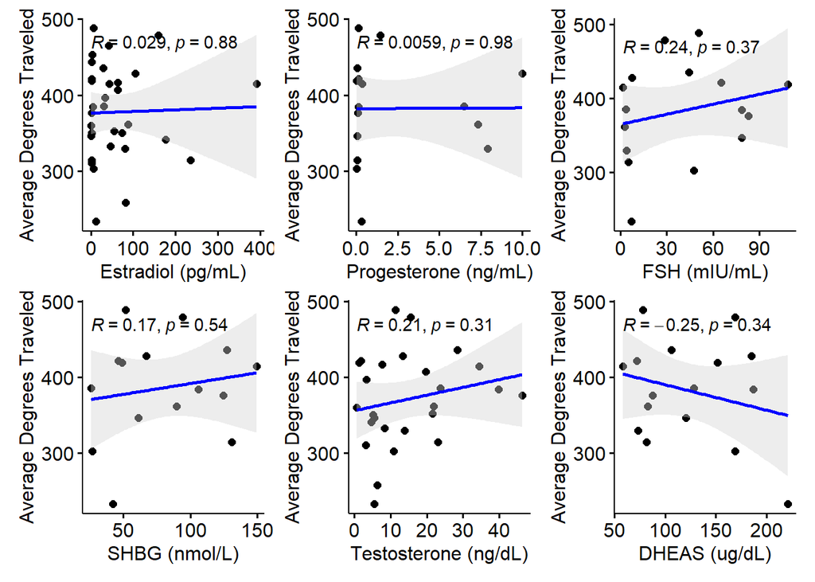

No associations between LOOP degrees traveled and hormones for women.

### MAZE

#### Accuracy

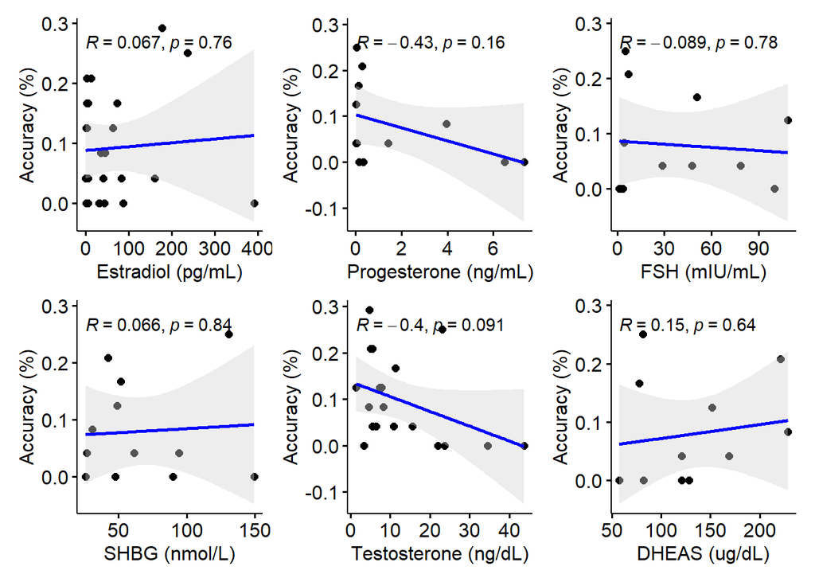

No association between MAZE accuracy and hormones for women.

#### Moves

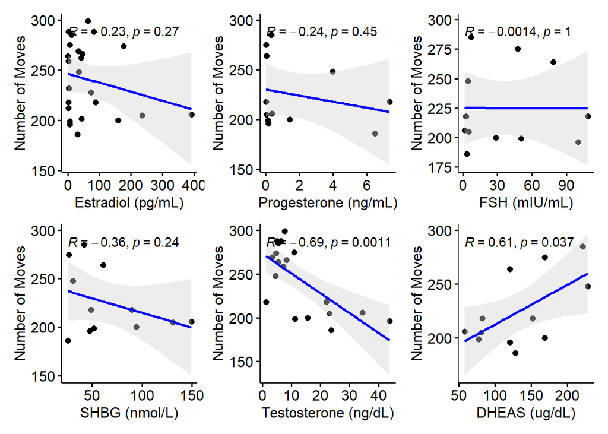

For MAZE moves, it seems to be positively associated with DHEAS and negatively associated with testosterone for women.

### DSP

#### Wayfinding Success

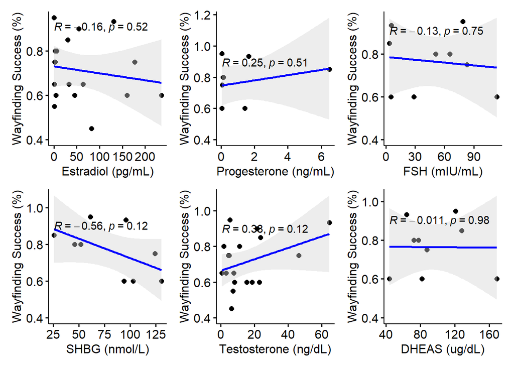

No associations between DSP wayfinding success and hormones for women.

#### Solution Index

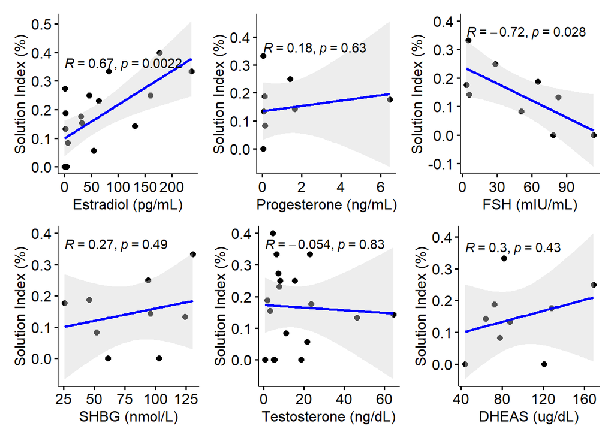

For DSP solution index, estradiol is positively associated and FSH is negatively associated in women.

# Summary

Future directions:

- Finish data collection and re-evaluate hormones with spatial navigation behaviors for men and women
- Consider missing hormones data for earlier participants who did SNAG only or did SNAG follow-ups (due to number of missing data from hormones, moving forward should we use hormone data taken during scan if available to substitute for missing spatial hormone data? It will improve sample size.)